# Exploratory Data Analysis: Credit Card Fraud

Peter Caya

January 25, 2017

## Distribution of Data

`{r summary}1 # Count NA values: NA_Counta <-apply(X = CC,MARGIN = 2,FUN = function(X){sum(is.na(X))}) # Determine the distribution of each of the different factors Melted_Data <- melt(CC) Melted_Frauds <- melt(CC[which(CC$Class==1),]) Melted_Legit <- melt(CC[which(!CC$Class==1),]) Melted_Data$Type <- "All Data" Melted_Frauds$Type <- "Frauds" Melted_Legit$Type <- "Normal" Plot_Data <-rbind(Melted_Data,Melted_Legit,Melted_Frauds) ggplot(data = Plot_Data %>% filter(grepl(x=variable,"V")) )+geom_boxplot(aes(x=variable,y=value ))+facet_grid(Type~.)+ggtitle("Features of Credit Card Data")+xlab("Features")`

[figure not shown]

Plot three shows an appreciable difference in the spending habits displayed between fraudulent and nonfraudulent transactions. The legitimate transactions display a wider range of values than the fraudulent transactions. Some of this appears to be related to outliers however.

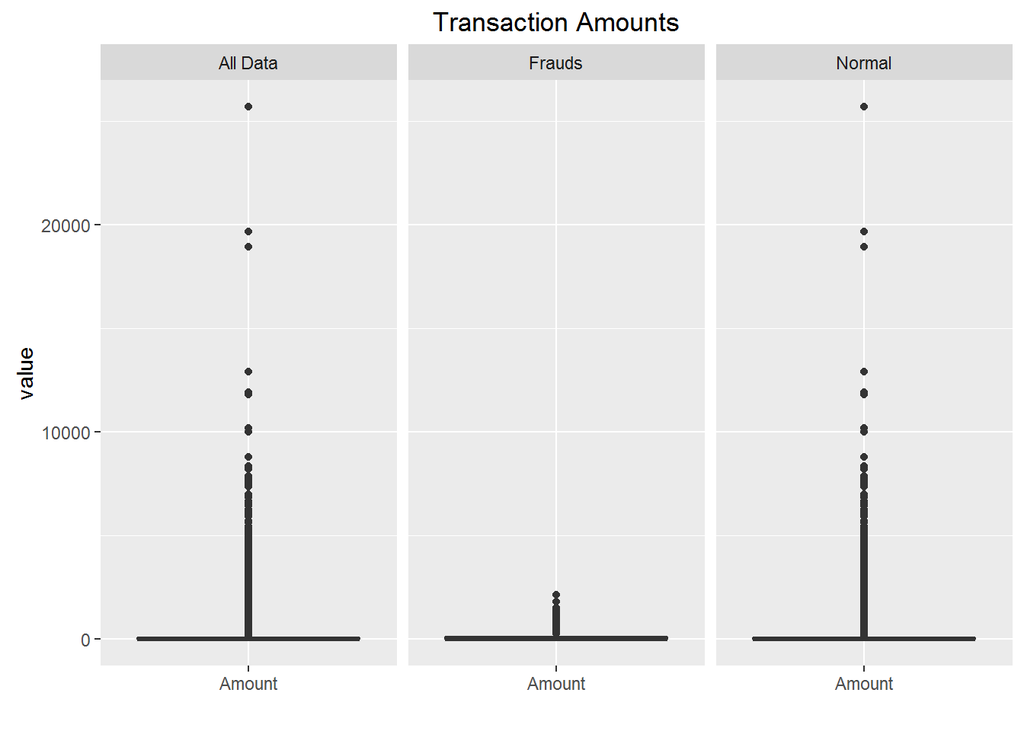

To get a better idea where values depart between the fraudulent and non-fraudelent data, it would be helpful to determine where the factors depart the most:

Summary Statistics for Difference Between Features for Legitimate and Fraudulent Transactions

|  | Min | 1Q | 2Q | Mean | 3Q | Max |
| --- | --- | --- | --- | --- | --- | --- |
| Time | -406.00 | 12990.00 | 9140.00 | 14090.00 | 10800.00 | 2500.00 |
| V1 | -25.86 | 5.12 | 2.36 | 4.78 | 1.74 | 0.32 |
| V2 | -64.32 | -1.79 | -2.65 | -3.63 | -4.17 | -3.16 |
| V3 | -17.23 | 7.76 | 5.26 | 7.05 | 3.30 | 7.13 |
| V4 | -4.37 | -3.22 | -4.20 | -4.55 | -5.61 | 4.77 |
| V5 | -91.59 | 4.10 | 1.47 | 3.16 | 0.40 | 23.70 |
| V6 | -19.75 | 1.74 | 1.15 | 1.40 | 0.81 | 66.83 |
| V7 | 11.80 | 7.41 | 3.08 | 5.58 | 1.52 | 114.80 |
| V8 | -32.18 | -0.01 | -0.60 | -0.57 | -1.44 | -1.30 |
| V9 | 7.14 | 3.23 | 2.16 | 2.59 | 1.39 | 12.24 |
| V10 | 9.85 | 7.22 | 4.49 | 5.69 | 3.07 | 19.72 |
| V11 | -3.09 | -2.74 | -3.62 | -3.81 | -4.57 | -2.02 |
| V12 | 3.54 | 8.29 | 5.64 | 6.27 | 3.59 | 6.47 |
| V13 | -2.66 | 0.33 | 0.05 | 0.11 | -0.01 | 4.31 |
| V14 | 0.82 | 9.27 | 6.78 | 6.98 | 4.78 | 7.09 |
| V15 | 0.11 | 0.06 | 0.11 | 0.09 | 0.04 | 6.41 |
| V16 | 4.01 | 6.10 | 3.62 | 4.15 | 1.75 | 14.18 |
| V17 | 8.06 | 11.47 | 5.24 | 6.68 | 1.74 | 2.51 |
| V18 | 4.13 | 4.17 | 1.66 | 2.25 | 0.41 | 1.25 |
| V19 | -3.53 | -0.16 | -0.64 | -0.68 | -1.19 | 0.36 |
| V20 | -50.37 | -0.04 | -0.35 | -0.37 | -0.69 | 28.36 |
| V21 | -12.03 | -0.27 | -0.62 | -0.71 | -1.06 | -4.59 |
| V22 | -2.04 | -0.01 | -0.04 | -0.01 | -0.09 | 2.14 |
| V23 | -25.56 | 0.18 | 0.06 | 0.04 | -0.16 | 17.06 |
| V24 | -0.81 | 0.08 | 0.10 | 0.11 | 0.15 | 3.49 |
| V25 | -5.52 | 0.00 | -0.07 | -0.04 | -0.11 | 5.31 |
| V26 | -1.45 | -0.07 | -0.06 | -0.05 | -0.16 | 0.77 |
| V27 | -15.31 | -0.05 | -0.39 | -0.17 | -0.74 | 28.56 |
| V28 | -13.56 | 0.06 | -0.14 | -0.08 | -0.30 | 32.07 |
| Amount | 0.00 | 4.65 | 12.75 | -33.91 | -28.85 | 23564.00 |

Standard Deviations for Difference Between Features for Legitimate and Fraudulent Transactions

|  | Legitimate Transactions | Fraudulent Transactions | Standard Deviation Difference |
| --- | --- | --- | --- |
| Time | 47484.02 | 47835.37 | -351.35 |
| V1 | 1.93 | 6.78 | -4.85 |
| V2 | 1.64 | 4.29 | -2.66 |
| V3 | 1.46 | 7.11 | -5.65 |
| V4 | 1.40 | 2.87 | -1.47 |
| V5 | 1.36 | 5.37 | -4.02 |
| V6 | 1.33 | 1.86 | -0.53 |
| V7 | 1.18 | 7.21 | -6.03 |
| V8 | 1.16 | 6.80 | -5.64 |
| V9 | 1.09 | 2.50 | -1.41 |
| V10 | 1.04 | 4.90 | -3.85 |
| V11 | 1.00 | 2.68 | -1.68 |
| V12 | 0.95 | 4.65 | -3.71 |
| V13 | 1.00 | 1.10 | -0.11 |
| V14 | 0.90 | 4.28 | -3.38 |
| V15 | 0.92 | 1.05 | -0.13 |
| V16 | 0.84 | 3.87 | -3.02 |
| V17 | 0.75 | 6.97 | -6.22 |
| V18 | 0.82 | 2.90 | -2.07 |
| V19 | 0.81 | 1.54 | -0.73 |
| V20 | 0.77 | 1.35 | -0.58 |
| V21 | 0.72 | 3.87 | -3.15 |
| V22 | 0.72 | 1.49 | -0.77 |
| V23 | 0.62 | 1.58 | -0.96 |
| V24 | 0.61 | 0.52 | 0.09 |
| V25 | 0.52 | 0.80 | -0.28 |
| V26 | 0.48 | 0.47 | 0.01 |
| V27 | 0.40 | 1.38 | -0.98 |
| V28 | 0.33 | 0.55 | -0.22 |
| Amount | 250.11 | 256.68 | -6.58 |

## Measuring Accuracy

One of the major issues with this dataset is that fraudulent transactions take up 0.17% of the data. This level precludes the use of conventional classification accuracy. A trivial model which automatically classifies a sample from our dataset as legitimate would have a very high accuracy while at the same time being completely useless for our purposes.

To measure the accuracy of proposed models I will employ the following measures of classification accuracy:

1. Kappa
2. Confusion matrices.
3. The area under the ROC curve.
4. The area under the precision recall curve.

## Sampling Methods

Two common approaches used to correct for imbalances in data are oversampling and undersampling. These methods process the data and add bias to the training dataset to compensate for data imbalance. In this scenario oversampling will involve taking a sample of $N$ different values from the data involving legitimate transactions and then selecting a large enough number of duplicate transactions from the fraudulent data to produce a dataset which contains a 50% balance of either category. Undersampling will involve sampling $N$ observations from the fraudulent data and then selecting a subset of the legitimate transactions which equal $N$.

Either of these methods has drawbacks. There are clear outliers evident in the features so undersampling is likely to ignore these potentionally datapoints. On the other hand, the use of oversampling for such an unbalanced dataset may be questionable due to potention overuse of the small dataset of fraudulent data.

As a result, both oversampled and undersampled datasets are used.

## Data Compression

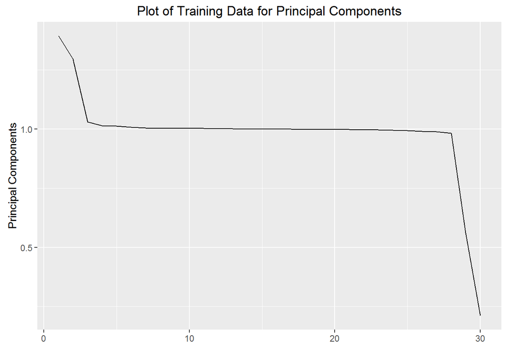

## Logistic Regression

#### Results From Oversampling

```
## Generalized Linear Model
##
## 454884 samples
##     30 predictor
##      2 classes: '0', '1'
##
## No pre-processing
## Resampling: Bootstrapped (25 reps)
## Summary of sample sizes: 454884, 454884, 454884, 454884, 454884, 454884, ...
## Resampling results:
##
##   Accuracy   Kappa
##   0.9463668  0.892731
##
##
```

```
## Bootstrapped (25 reps) Confusion Matrix
##
## (entries are percentual average cell counts across resamples)
##
##           Reference
## Prediction    0    1
##          0 48.7  4.1
##          1  1.3 45.9
##
##  Accuracy (average) : 0.9464
```

#### Results From Undersampling

```
## Generalized Linear Model
##
## 806 samples
##  30 predictor
##   2 classes: '0', '1'
##
## No pre-processing
## Resampling: Bootstrapped (25 reps)
## Summary of sample sizes: 806, 806, 806, 806, 806, 806, ...
## Resampling results:
##
##   Accuracy   Kappa
##   0.9074007  0.8148349
##
##
```

```
## Bootstrapped (25 reps) Confusion Matrix
##
## (entries are percentual average cell counts across resamples)
##
##           Reference
## Prediction    0    1
##          0 47.0  6.0
##          1  3.3 43.6
##
##  Accuracy (average) : 0.9065
```

#### Results Using Initial Data

```
## Generalized Linear Model
##
## 227845 samples
##     30 predictor
##      2 classes: '0', '1'
##
## No pre-processing
## Resampling: Bootstrapped (25 reps)
## Summary of sample sizes: 227845, 227845, 227845, 227845, 227845, 227845, ...
## Resampling results:
##
##   Accuracy   Kappa
##   0.9991539  0.7159889
##
##
```

```
## Bootstrapped (25 reps) Confusion Matrix
##
## (entries are percentual average cell counts across resamples)
##
##           Reference
## Prediction    0    1
##          0 99.8  0.1
##          1  0.0  0.1
##
##  Accuracy (average) : 0.9992
```

### Results on testing data.

```
## Confusion Matrix and Statistics
##
##           Reference
## Prediction     0     1
##          0 55457     5
##          1  1416    84
##
##                Accuracy : 0.9751
##                  95% CI : (0.9737, 0.9763)
##     No Information Rate : 0.9984
##     P-Value [Acc > NIR] : 1
##
##                   Kappa : 0.1031
##  Mcnemar's Test P-Value : <2e-16
##
##             Sensitivity : 0.9751
##             Specificity : 0.9438
##          Pos Pred Value : 0.9999
##          Neg Pred Value : 0.0560
##              Prevalence : 0.9984
##          Detection Rate : 0.9736
##    Detection Prevalence : 0.9737
##       Balanced Accuracy : 0.9595
##
##        'Positive' Class : 0
##
```

```
## Confusion Matrix and Statistics
##
##           Reference
## Prediction     0     1
##          0 54506     8
##          1  2367    81
##
##                Accuracy : 0.9583
##                  95% CI : (0.9566, 0.9599)
##     No Information Rate : 0.9984
##     P-Value [Acc > NIR] : 1
##
##                   Kappa : 0.061
##  Mcnemar's Test P-Value : <2e-16
##
##             Sensitivity : 0.95838
##             Specificity : 0.91011
##          Pos Pred Value : 0.99985
##          Neg Pred Value : 0.03309
##              Prevalence : 0.99844
##          Detection Rate : 0.95688
##    Detection Prevalence : 0.95702
##       Balanced Accuracy : 0.93425
##
##        'Positive' Class : 0
##
```

```
## Confusion Matrix and Statistics
##
##           Reference
## Prediction     0     1
##          0 56864    30
##          1     9    59
##
##                Accuracy : 0.9993
##                  95% CI : (0.9991, 0.9995)
##     No Information Rate : 0.9984
##     P-Value [Acc > NIR] : 1.99e-09
##
##                   Kappa : 0.7513
##  Mcnemar's Test P-Value : 0.001362
##
##             Sensitivity : 0.9998
##             Specificity : 0.6629
##          Pos Pred Value : 0.9995
##          Neg Pred Value : 0.8676
##              Prevalence : 0.9984
##          Detection Rate : 0.9983
##    Detection Prevalence : 0.9988
##       Balanced Accuracy : 0.8314
##
##        'Positive' Class : 0
##
```